# OpenSpaces Data Prep

true

Updated on: 2022-04-13

```r
gmRi::use_gmri_style_rmd()
```

# Contents:

1. Progression of Anomalies in NE Atlantic (annual, seasonal)
2. Representation of Warming Rates
3. Thermal habitat of BSB
4. Movement of BSB?

## Prepare Monthly SST Data

Looking at it from a thermal preference angle, there is the possibility to look at temperature suitability. This could be summer or winter displays of temperature envelopes that fit their thermal preferences.

**Reference on Habitat Suitability** https://journals.plos.org/plosone/article/file?id=10.1371/journal.pone.0147627&type=printable

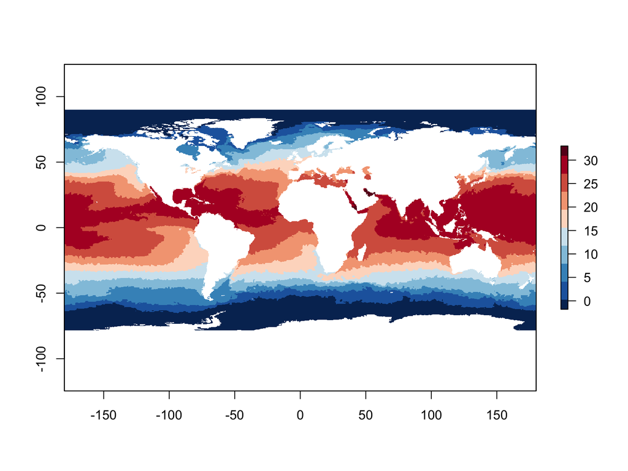

```r
# Load Raster
month_sst <- raster::stack(str_c(oisst_path, "monthly_averages/oisst_monthly.nc"), varname = "sst")

# Rename
names(month_sst) <- str_replace_all(str_sub(names(month_sst), 2, -1), "[.]", "-")

# Plot
plot(rotate(month_sst$X1981.09.30), col = temp_pal)
```

### 1. Pull September Averages

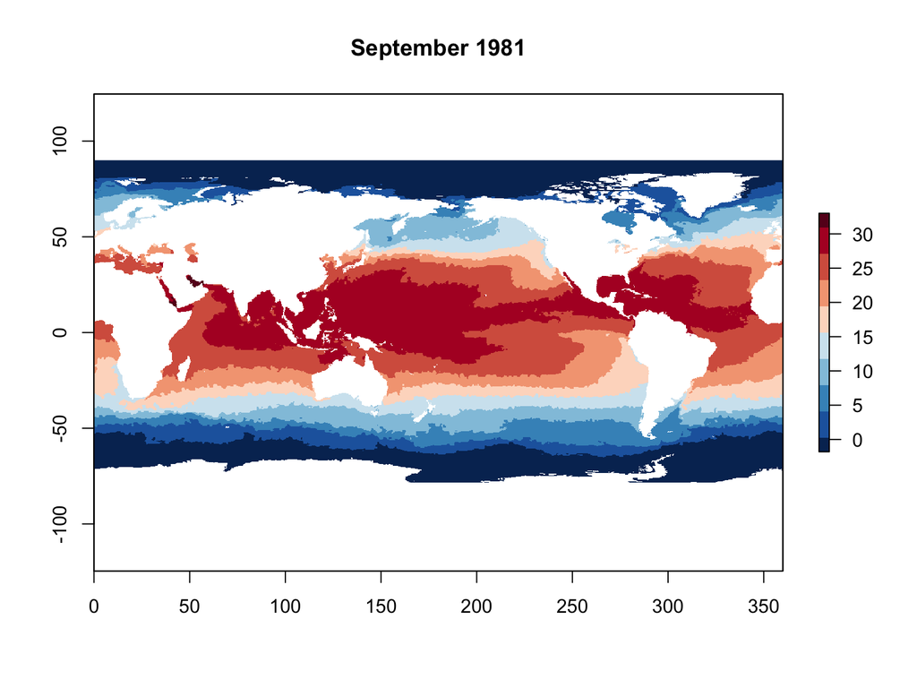

```r
# Pull Just September:
month_sept <- month_sst[[which(str_sub(names(month_sst), 7, 8) == "09")]]

plot(month_sept$X1981.09.30, col = temp_pal, main = "September 1981")
```

### 2. Crop to Our Area

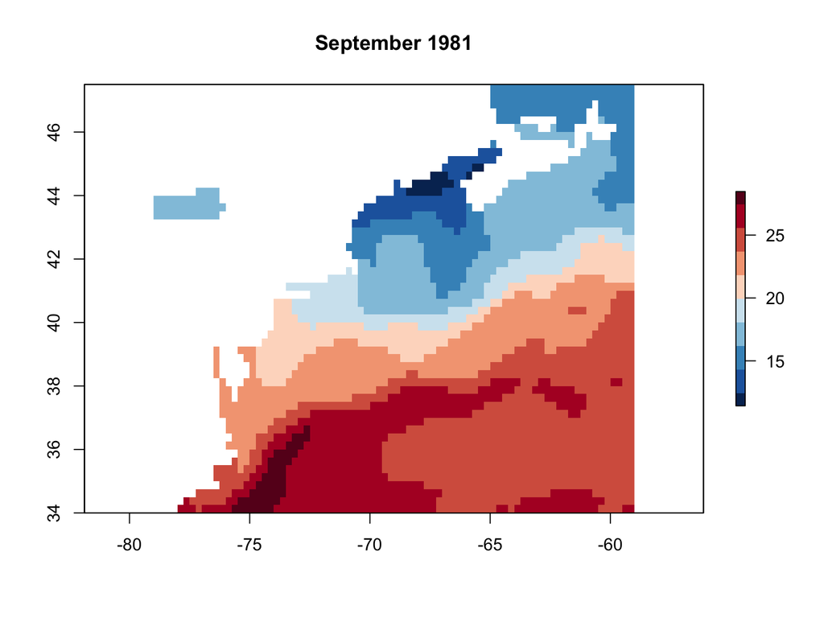

```r
# Cropping Extent
crop_extent <- make_cropbox(xlims = c(-79, -59),
                            ylims = c(34, 47.5))
#st_crs(crop_extent) <- crs(month_sst)

# Crop it
gom_monthly <- mask_nc(month_sept, mask_shape = crop_extent, rotate = T)

# Plot a tester:
plot(gom_monthly$X1981.09.30, col = temp_pal, main = "September 1981")
```

### 3. Consolidate Into Decades

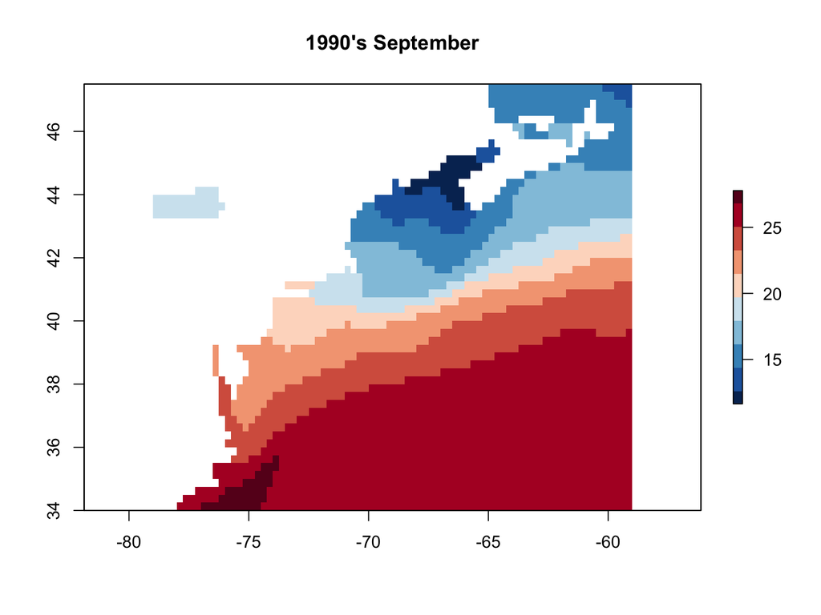

```r
# Decades
decades <- list(
  "1990s" = 199,
  "2000s" = 200,
  "2010s" = 201)


# Get the mean temp for each decade
temp_decades <- map(decades, function(decade_id){
  year_layers <- which(str_sub(names(gom_monthly), 2, 4) == decade_id)
  decade_dat <- gom_monthly[[year_layers]]
  decade_mean <- mean(decade_dat, na.rm = T)
  return(decade_mean)


}) %>% stack()

plot(temp_decades$X1990s, main = "1990's September", col = temp_pal)
```

### 4. Cover Data from the Great Lakes

[figure not shown]

```r
# Make a shape for the area
lakes_cover <- make_cropbox(xlims = c(-80, -75),
                            ylims = c(43, 45))


#lakes_ras <- mask(temp_decades[[1]], lakes_cover, inverse = TRUE)

# Mask that region
temp_decades <- mask(temp_decades, lakes_cover, inverse = TRUE)
plot(temp_decades$X1990s, main = "1990's September", col = temp_pal)
```

### 5. Enhance the Resolution

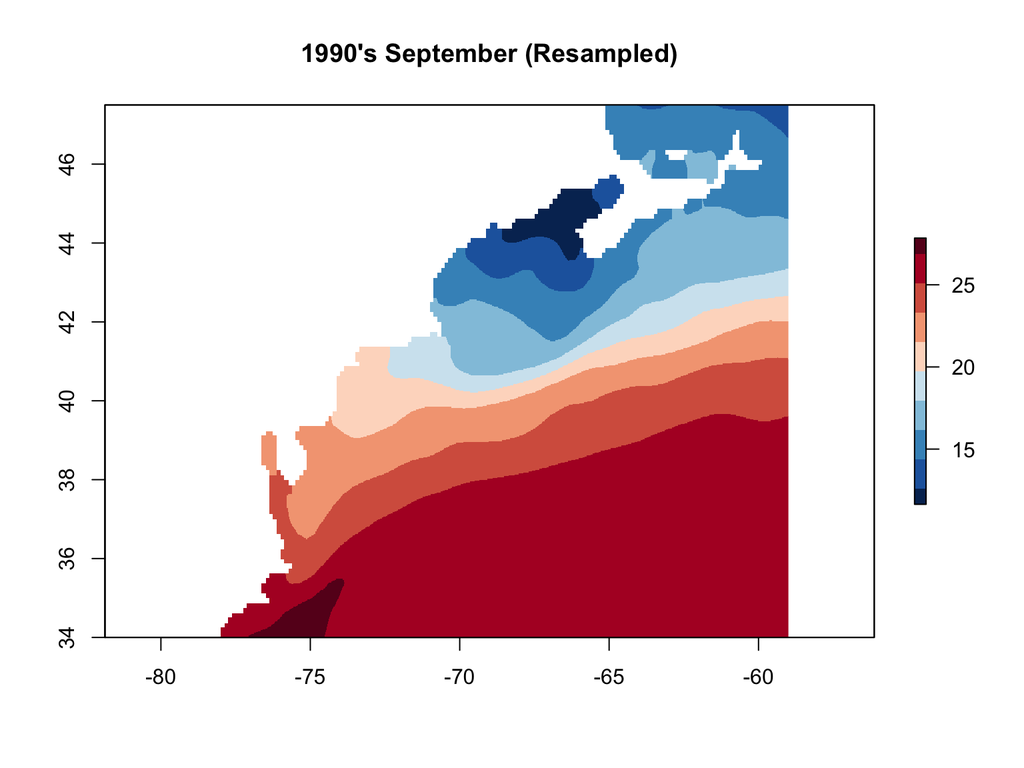

```r
# Resample to Finer Resolution
# Helps it look better if the grid makes squares
s <- raster(nrow = 1400,
            ncol = 2000,
            xmn = extent(crop_extent)[1],
            xmx = extent(crop_extent)[2],
            ymn = extent(crop_extent)[3],
            ymx = extent(crop_extent)[4])

# Resample to higher resolution
temp_hires <- raster::resample(temp_decades, s)

# check one
plot(temp_hires$X1990s, main = "1990's September (Resampled)", col = temp_pal)
```

## Decadal Temperature Shifts

The decadal average temperatures for the region are as follows:

### 1990’s

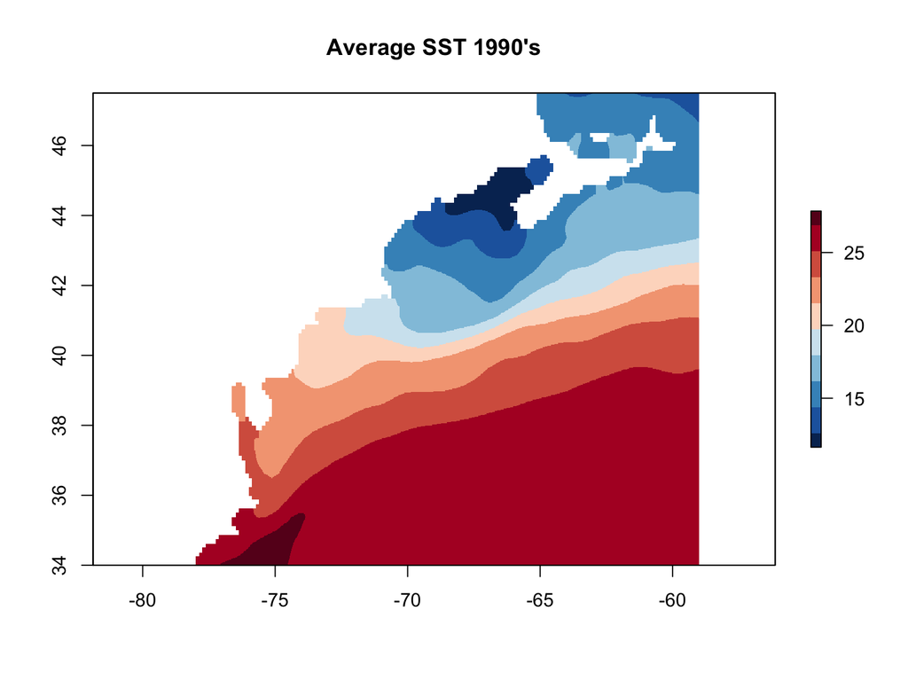

```r
plot(temp_hires$X1990s, main = "Average SST 1990's", col = temp_pal)
```

### 2000’s

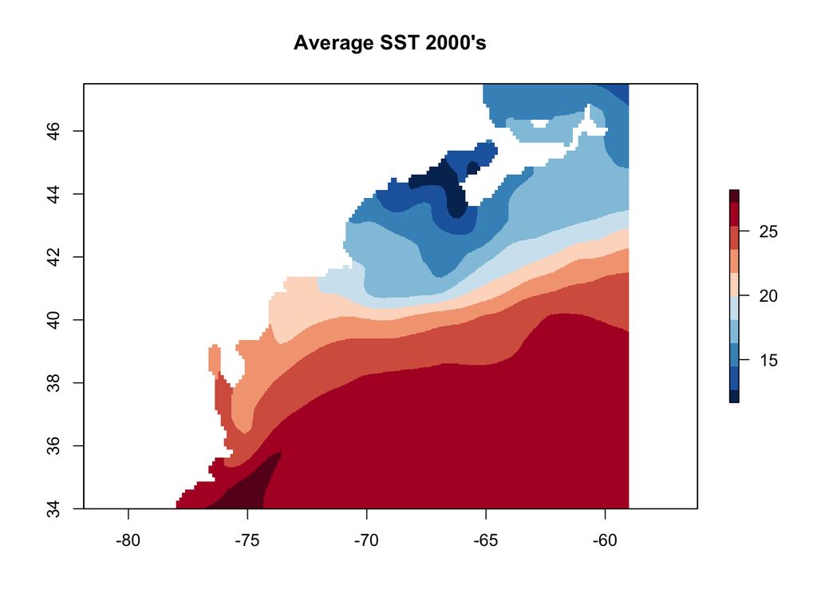

```r
plot(temp_hires$X2000s, main = "Average SST 2000's", col = temp_pal)
```

### 2010’s

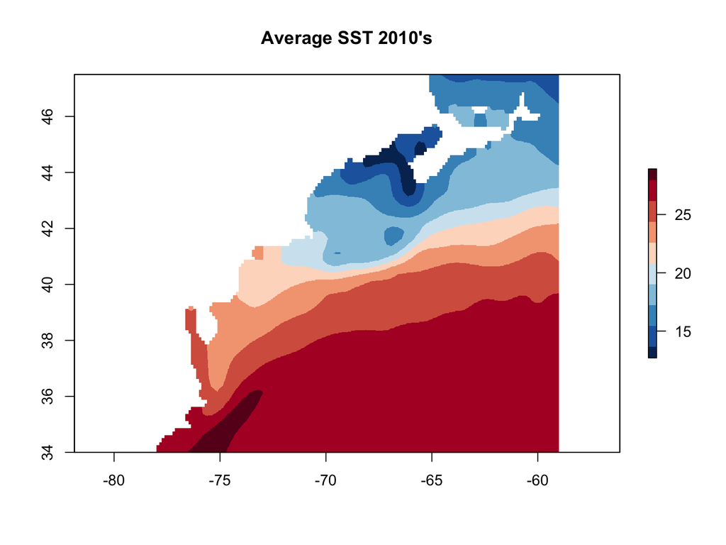

```r
plot(temp_hires$X2010s, main = "Average SST 2010's", col = temp_pal)
```

# Thermal Preference Curves

Knowing that the temperatures globally are changing, it is logical to anticipate species to adjust their movements and behaviors to follow their thermal preferences.

From historical datasets and experiments we are able to determine the range of temperatures that species need and/or prefer in order to live.

Knowing these limits then lets us project onto a map where those conditions exist and where conditions are less-tolerable.

```r
# Get temperature range for study area as a vector
temp_range <- seq(min(values(gom_monthly), na.rm = T),
                  max(values(gom_monthly), na.rm = T),
                  by = .1)




# Function to make preference rasters:
make_pref_ras <- function(in_ras, ras_name, p1, p2, alpha, gamma){

  # Make a new raster that we can swap values from
  pref_ras <- in_ras[[ras_name]]

  # Assign values based on preference curve
  values(pref_ras) <- betaFun(
    values(pref_ras),
    p1 = p1,
    p2 = p2,
    alpha = alpha,
    gamma = gamma)

  return(pref_ras)


}
```

## Black Seas Bass

Black Sea Bass have a thermal preference (from fall survey data) of 18-25C or 64-77F.

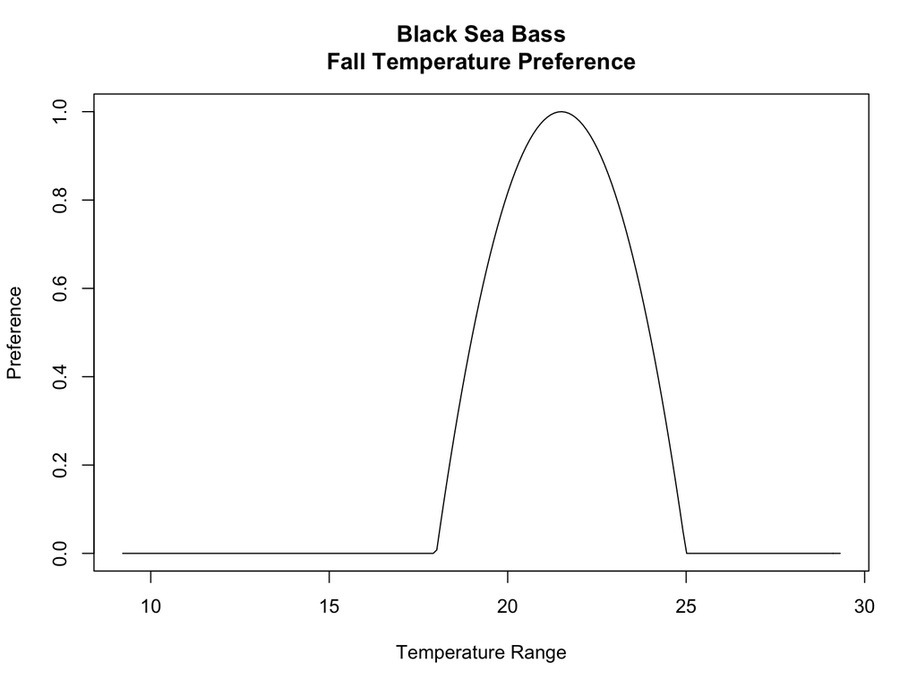

```r
# Use the betaFun(), feed it temperature vector min/max and curve shape
bsb_beta <- betaFun(
  x = temp_range,
        p1 = 18,
        p2 = 25,
        alpha = 1,
        gamma = 1)


# Show the temp  preference
plot(bsb_beta ~ temp_range, type = "l", main = "Black Sea Bass\nFall Temperature Preference", ylab = "Preference", xlab = "Temperature Range")
```

```r
# Run thermal preference for each year
hires_list <- unstack(temp_hires) %>% setNames(names(temp_hires))
bsb_prefs <- imap(hires_list, make_pref_ras, p1 = 18, p2 = 25, alpha = 1, gamma = 1)
```

### Sea Bass 1990’s

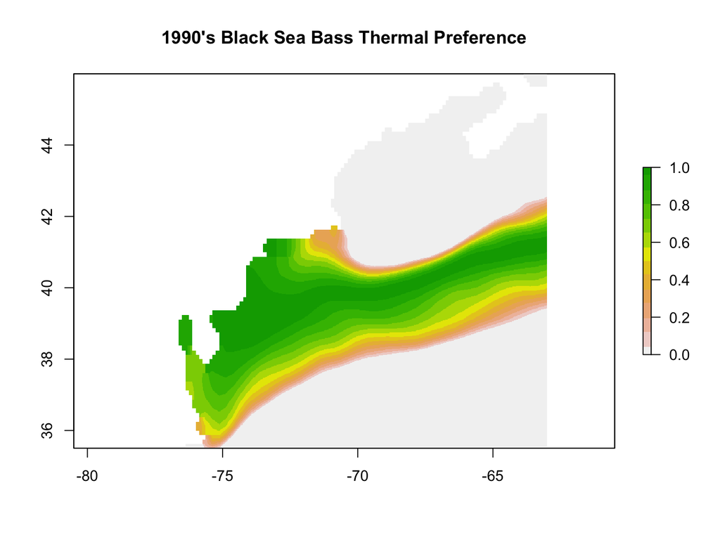

```r
plot(bsb_prefs$X1990s,
     main = "1990's Black Sea Bass Thermal Preference",
     col = terrain.colors(14, rev = T),
     xlim = c(-78, -63),
     ylim = c(35.5,46))
```

### Sea Bass 2000’s

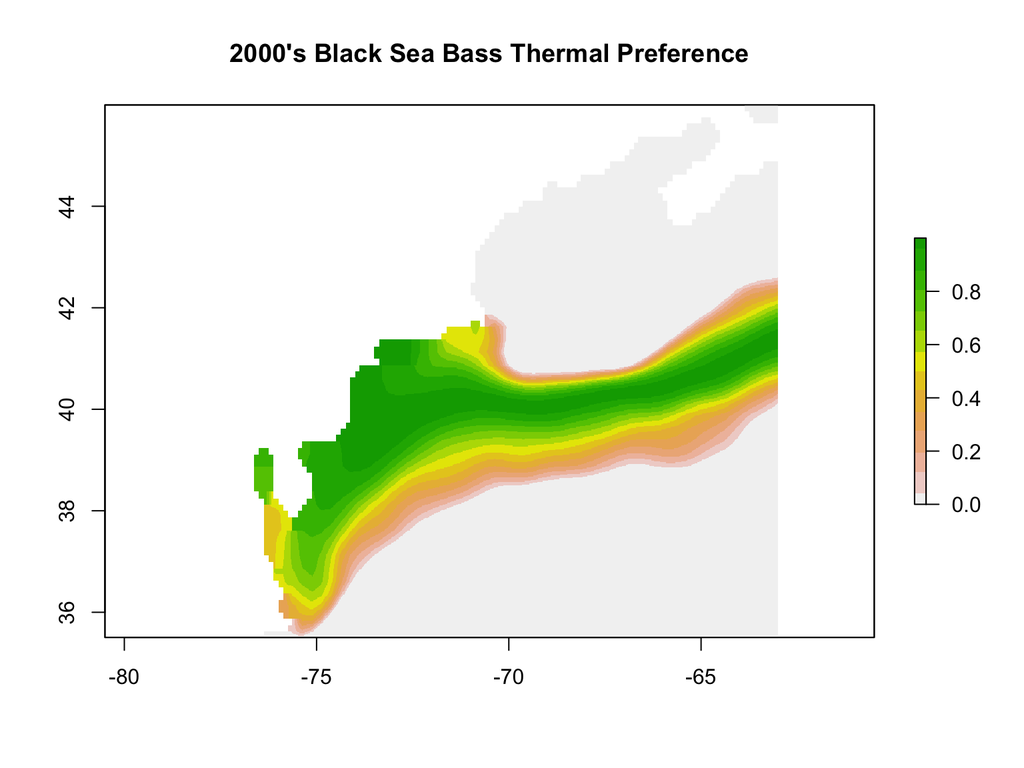

```r
plot(bsb_prefs$X2000s,
     main = "2000's Black Sea Bass Thermal Preference",
     col = terrain.colors(14, rev = T),
     xlim = c(-78, -63),
     ylim = c(35.5,46))
```

### Sea Bass 2010’s

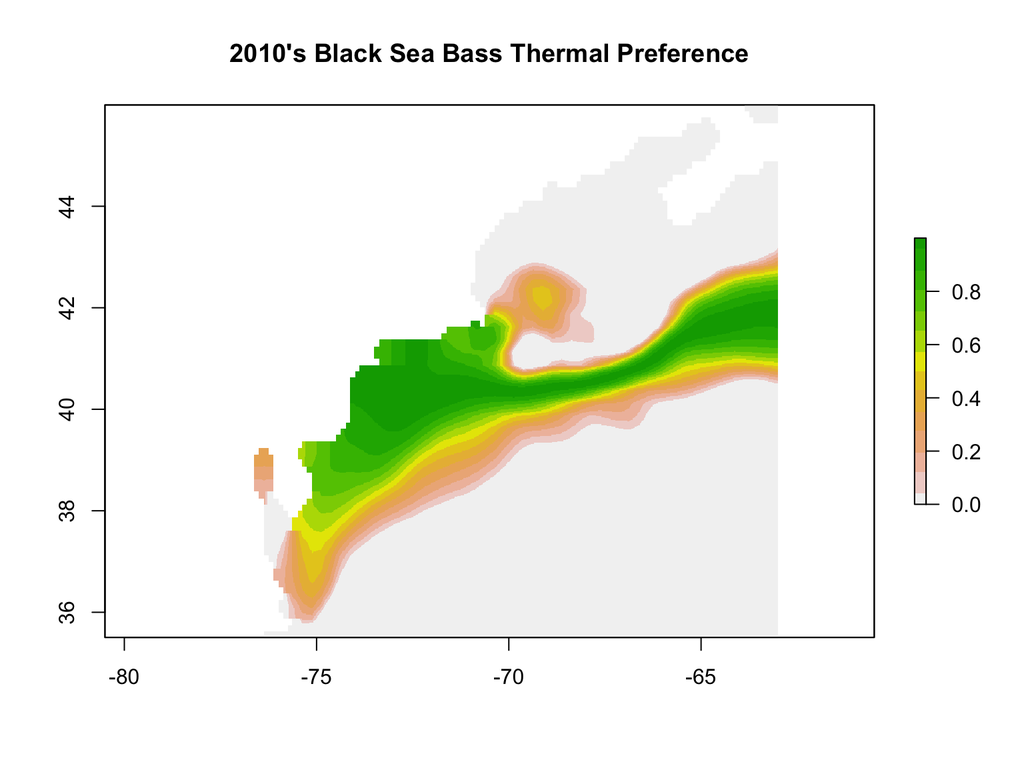

```r
plot(bsb_prefs$X2010s,
     main = "2010's Black Sea Bass Thermal Preference",
     col = terrain.colors(14, rev = T),
     xlim = c(-78, -63),
     ylim = c(35.5,46))
```

## Lobster

Lobster have a thermal preference (lab venture) of 11-22C.

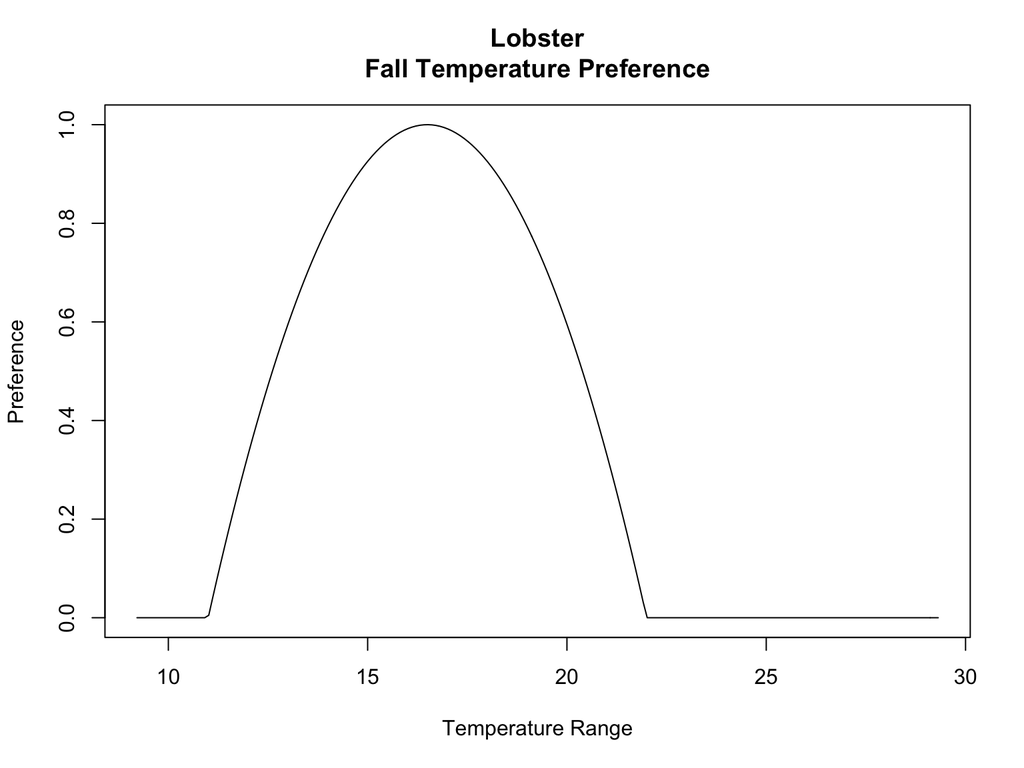

```r
# Use the betaFun(), feed it temperature vector min/max and curve shape
lob_beta <- betaFun(
  x = temp_range,
        p1 = 11,
        p2 = 22,
        alpha = 1,
        gamma = 1)


# Show the temp  preference
plot(lob_beta ~ temp_range, type = "l", main = "Lobster\nFall Temperature Preference", ylab = "Preference", xlab = "Temperature Range")
```

```r
# Run thermal preference for each year
lob_prefs <- imap(hires_list, make_pref_ras, p1 = 11, p2 = 22, alpha = 1, gamma = 1)
```

### Lobster 1990’s

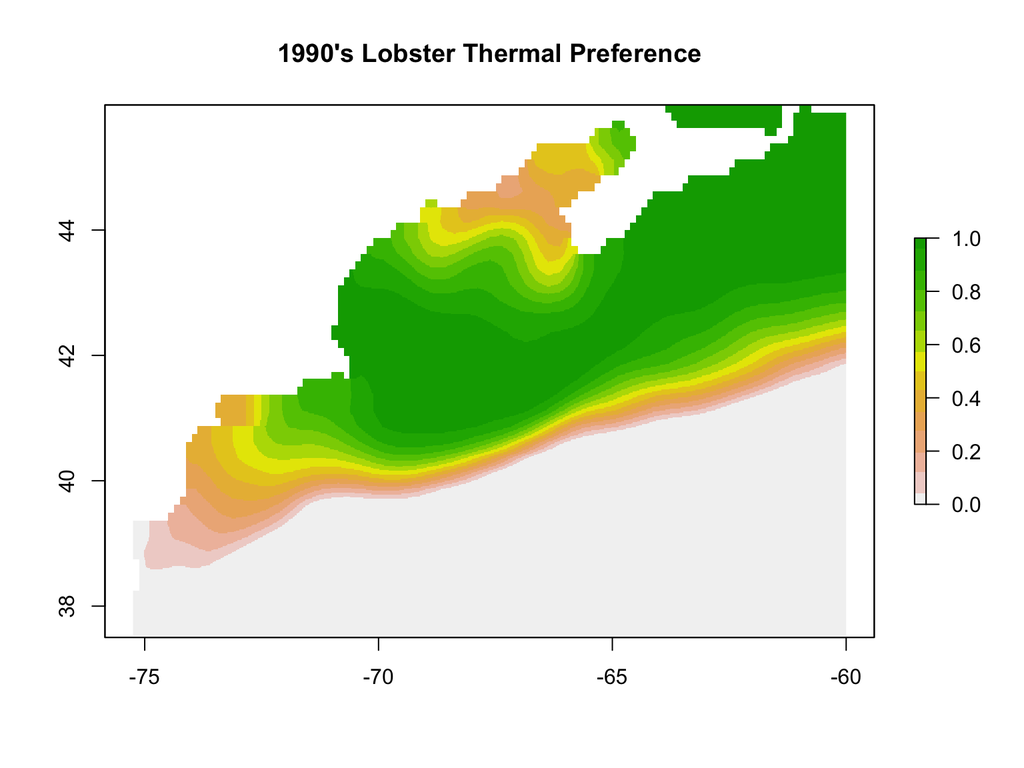

```r
plot(lob_prefs$X1990s,
     main = "1990's Lobster Thermal Preference",
     col = terrain.colors(14, rev = T),
     xlim = c(-75.25, -60),
     ylim = c(37.5,46))
```

### Lobster 2000’s

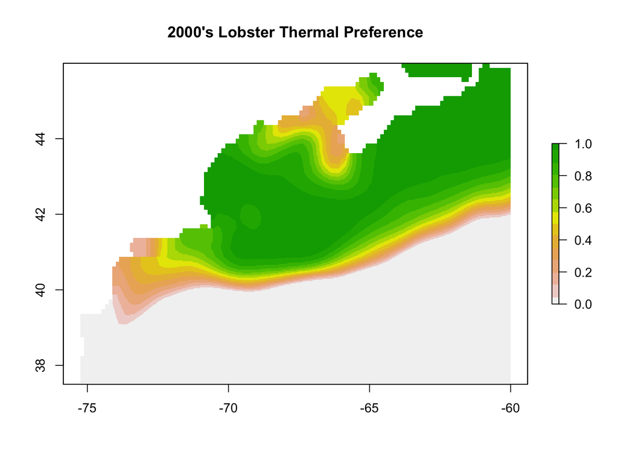

```r
plot(lob_prefs$X2000s,
     main = "2000's Lobster Thermal Preference",
     col = terrain.colors(14, rev = T),
     xlim = c(-75.25, -60),
     ylim = c(37.5,46))
```

### Lobster 2010’s

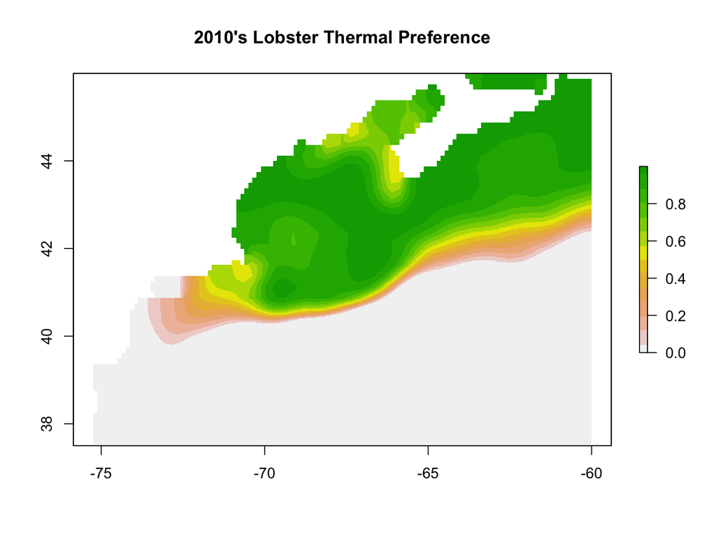

```r
plot(lob_prefs$X2010s,
     main = "2010's Lobster Thermal Preference",
     col = terrain.colors(14, rev = T),
     xlim = c(-75.25, -60),
     ylim = c(37.5,46))
```

## Global Warming Rates

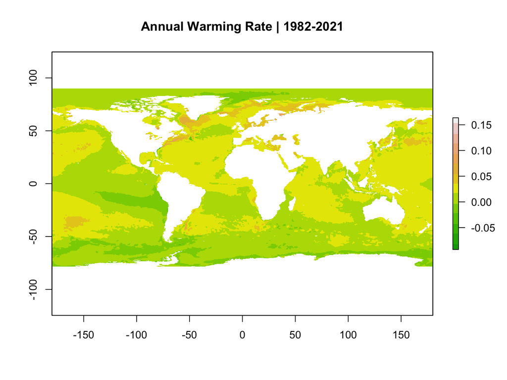

```r
# Load warming rates
annual_rates <- raster::stack(str_c(oisst_path, "warming_rates/annual_warming_rates1982to2021.nc"),
                              varname  = "annual_warming_rate")


# Plot Rates
plot(rotate(annual_rates),
     main = "Annual Warming Rate | 1982-2021",
     col = terrain.colors(14))
```

## Local Rates

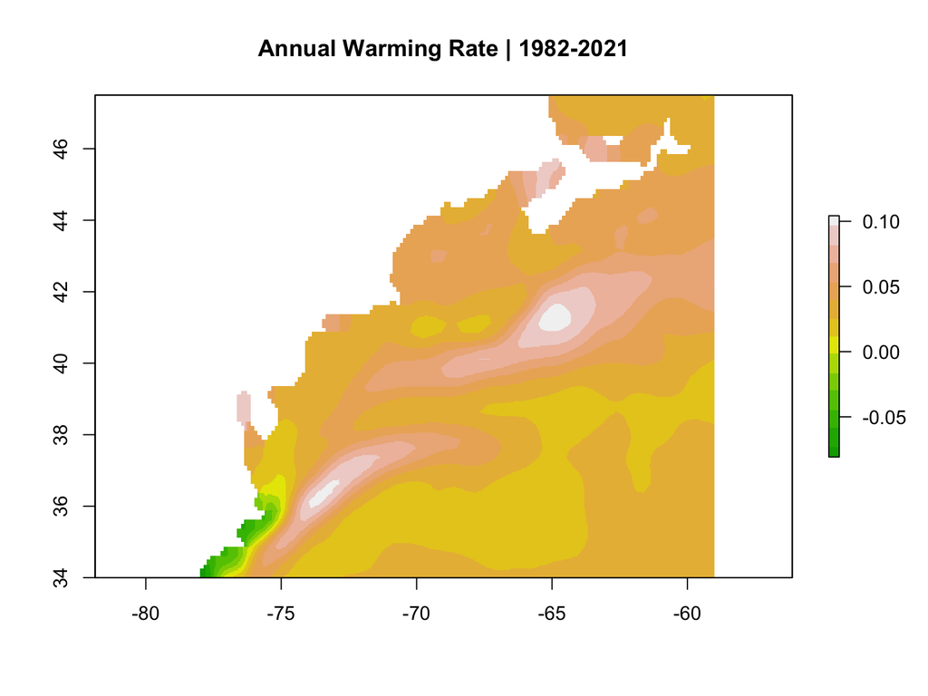

```r
# # Crop to local area:
rates_gom <- mask_nc(ras_obj = annual_rates, mask_shape = crop_extent, rotate = T)

# Mask that region
rates_gom <- mask(rates_gom, lakes_cover, inverse = TRUE)

# Resample to higher resolution
rates_hires <- raster::resample(rates_gom, s)

# Plot Rates
plot(rates_hires,
     main = "Annual Warming Rate | 1982-2021",
     col = terrain.colors(14))
```

## Global Warming Ranks

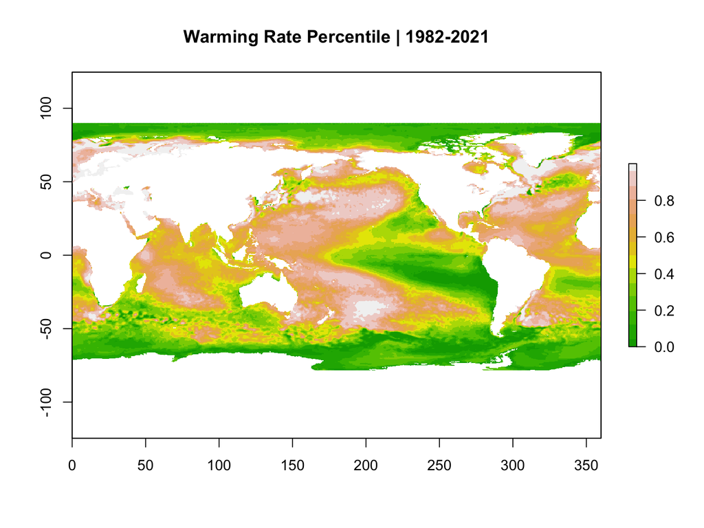

```r
# Plot Ranks:
annual_ranks <- raster::stack(str_c(oisst_path, "warming_rates/annual_warming_rates1982to2021.nc"),
                              varname  = "rate_percentile")
plot(annual_ranks,
     main = "Warming Rate Percentile | 1982-2021",
     col = terrain.colors(14))
```

## Local Ranks

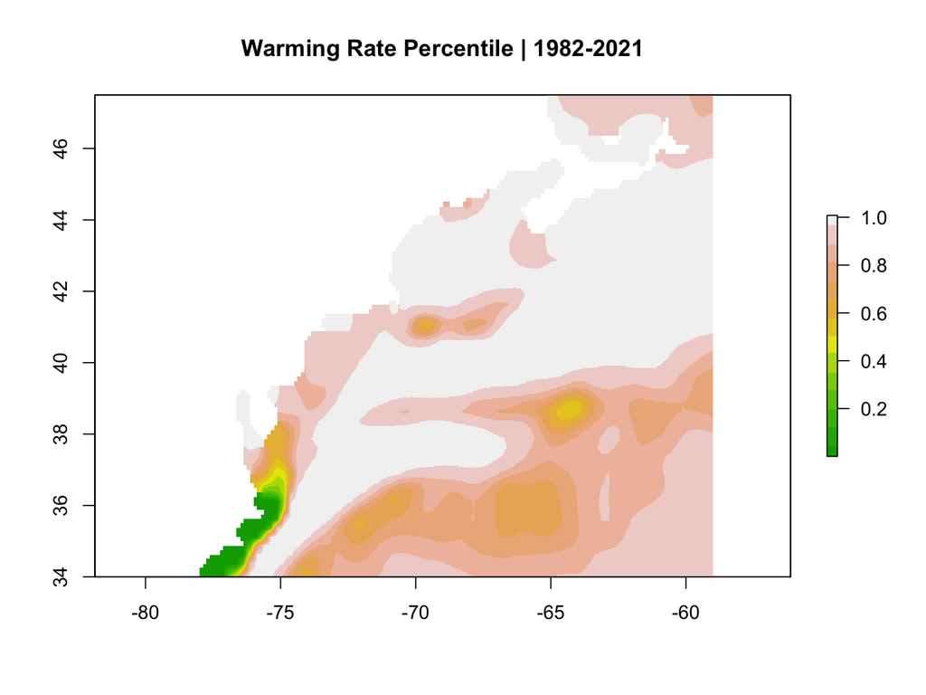

```r
# # Crop to local area:
ranks_gom <- mask_nc(ras_obj = annual_ranks, mask_shape = crop_extent, rotate = T)

# Mask that region
ranks_gom <- mask(ranks_gom, lakes_cover, inverse = TRUE)

# Resample to higher resolution
ranks_hires <- raster::resample(ranks_gom, s)

# Plot Ranks
plot(ranks_hires,
     main = "Warming Rate Percentile | 1982-2021",
     col = terrain.colors(14))
```

## Bounding the gulf Stream?

# Saving Geotiffs

To make the data available to openspaces the requested filetype is a GeoTiff

This stackoverflow question asks details aroundhow those can be saved from R: https://gis.stackexchange.com/questions/257204/saving-geotiff-from-r

```r
# Folder location
out_location <- here::here("R/markdown_reports/Openspaces_data")

# List of things to save
tiff_list <- list(
  "sst1990" = temp_hires$X1990s,
  "sst2000" = temp_hires$X2000s,
  "sst2010" = temp_hires$X2010s,
  "bsb1990" = bsb_prefs$X1990s,
  "bsb2000" = bsb_prefs$X2000s,
  "bsb2010" = bsb_prefs$X2010s,
  "lob1990" = lob_prefs$X1990s,
  "lob2000" = lob_prefs$X2000s,
  "lob2010" = lob_prefs$X2010s,
  "annualrates" = rates_hires$Annual.Sea.Surface.Temperature.Warming.Rate,
  "annualranks" = ranks_hires$Annual.Sea.Surface.Temperature.Warming.Rate.Rank
)

# Saving Something
test_save <- tiff_list[1]


# Save a geotiff
iwalk(tiff_list, function(x, y){
  writeRaster(x, filename = str_c(out_location, "/", y, ".tif"), options=c('TFW=YES'), overwrite = TRUE)
  message(str_c("Saving geoTiff: ", y))
})
```

```python
import rasterio as rio
```